# 2025_09_24 SARIMA, lecture notes

Published

# Preliminaries

```r
########################################################################################
##############       Forecasting:      SARIMA models        ############################
########################################################################################


library(MLTools)
library(fpp2)
library(readxl)
library(tidyverse)
library(TSstudio)
library(lmtest)  #contains coeftest function
library(tseries) #contains adf.test function
```

### Set working directory

```r
setwd(dirname(rstudioapi::getActiveDocumentContext()$path))
```

# Car Registration Example

#### Load dataset

```r
fdata <- read_excel("CarRegistrations.xls")
```

#### Visualize the first rows:

```r
head(fdata)
```

```
# A tibble: 6 × 2
  Fecha               CarReg
  <dttm>               <dbl>
1 1960-01-01 00:00:00   3.36
2 1960-02-01 00:00:00   4.38
3 1960-03-01 00:00:00   4.06
4 1960-04-01 00:00:00   5.38
5 1960-05-01 00:00:00   6.31
6 1960-06-01 00:00:00   4.02
```

#### Convert character columns to R date type

```r
fdata$Fecha <- as.Date(fdata$Fecha, format = "%d/%m/%Y")
head(fdata)
```

```
# A tibble: 6 × 2
  Fecha      CarReg
  <date>      <dbl>
1 1960-01-01   3.36
2 1960-02-01   4.38
3 1960-03-01   4.06
4 1960-04-01   5.38
5 1960-05-01   6.31
6 1960-06-01   4.02
```

#### Order the table by date (using the pipe operator)

```r
fdata <- fdata %>% arrange(Fecha)
```

This is the same as: `fdata <- arrange(fdata, Fecha)`

#### Check for missing dates (time gaps)

```r
range(fdata$Fecha)
```

```
[1] "1960-01-01" "1999-12-01"
```

Create a complete sequence of months with the same range and compare it to the dates in our data.

```r
date_range <- seq.Date(min(fdata$Fecha), max(fdata$Fecha), by = "months")

date_range[!date_range %in% fdata$Fecha]
```

```
Date of length 0
```

We also check for duplicates

```r
fdata %>%
  select(Fecha) %>%
  duplicated() %>%
  which()
```

```
integer(0)
```

#### Check for missing data (NA) in time series value columns

```r
sum(is.na(fdata$CarReg))
```

```
[1] 0
```

#### Convert it to a time series object

This is monthly data, so the frequency is 12. The series start in January. If it starts in e.g. April we would use start = c(1960, 4)

```r
freq <- 12
start_date  <-  c(1960, 1)
y <- ts(fdata$CarReg, start = start_date, frequency = freq)
```

#### Time plot:

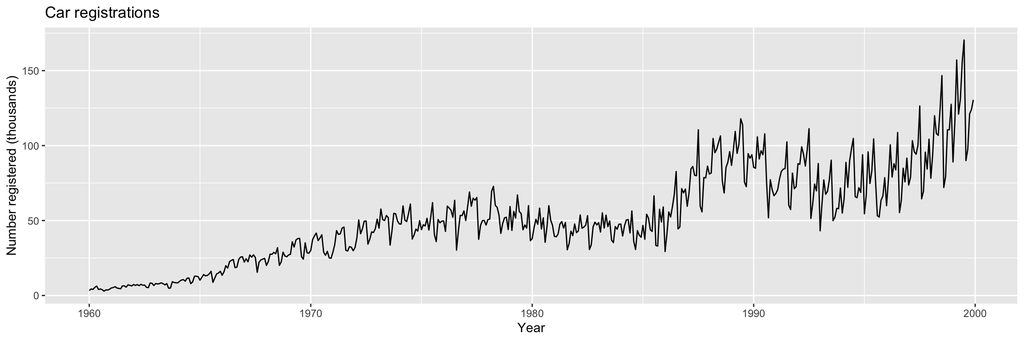

```r
autoplot(y) +
  ggtitle("Car registrations") +
  xlab("Year") + ylab("Number registered (thousands)")
```

## Train/test split

The train/test split method in forecasting needs to take the temporal structure into account, as illustrated in this picture (from Section 3.4 of Hyndman & Athanasopoulos (2018))

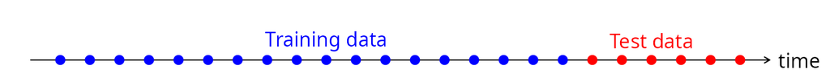

```
n <- length(y)
```

We will leave the last 5 years for validation

```r
n_test <- floor(5 * freq)

y_split <- ts_split(y, sample.out = n_test)
y.TR <- y_split$train
y.TV <- y_split$test
```

Alternatively, with `subset`

```r
# Line 39 of Lab4
y.TR <- subset(y, end = length(y) - 5 * 12)
y.TV <- subset(y, start = length(y) - 5 * 12 + 1)
```

Or even with `head` and `tail`:

```r
y.TR <- head(y, length(y) - 5 * 12)
y.TV <- tail(y, 5 * 12)
```

In fact it is usually a good idea to check the split using `head` and `tail` to see the last elements of training and the first ones of `test`:

```r
tail(y.TR)
```

```
         Jul     Aug     Sep     Oct     Nov     Dec
1994 104.812  65.899  65.201  71.931  68.761  93.883
```

```r
head(y.TV)
```

```
         Jan     Feb     Mar     Apr     May     Jun
1995  54.513  66.954  95.812  74.758  82.887 104.472
```

And let us also visualize the split.

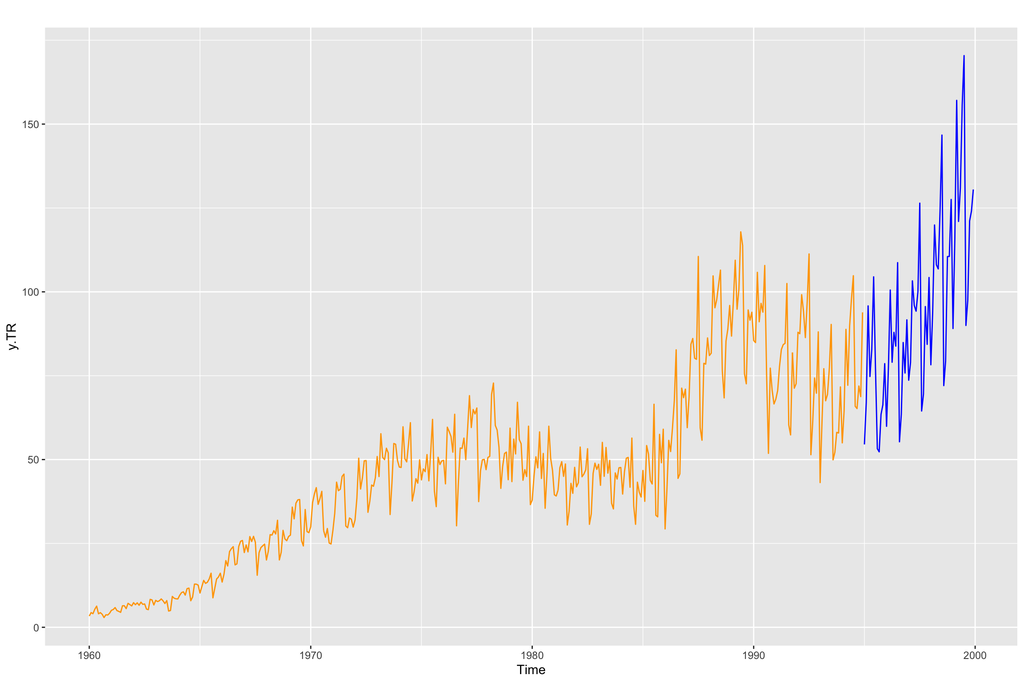

```r
autoplot(y.TR, color = "orange") +
  autolayer(y.TV, color = "blue")
```

### What if I don’t know the sampling rate of the time series?

Donwload the following data file: fdata2.dat

Let us use plots to explore the series

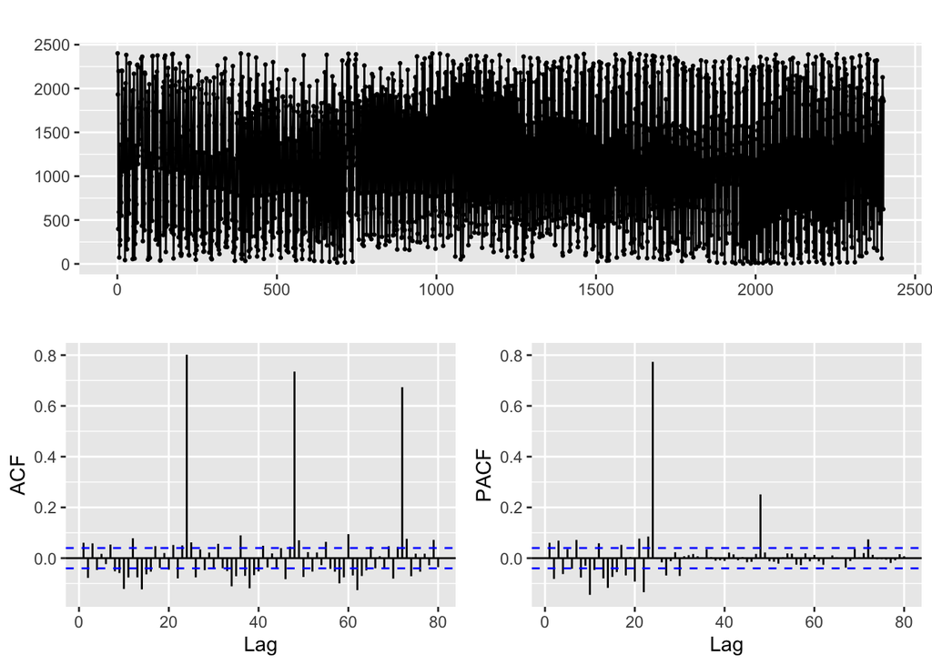

```r
fdata2 <- ts(read.table("fdata2.dat", sep = ""))

ggtsdisplay(fdata2, lag.max = 80)
```

Let us try that and emphasize the lags we suspect to be relevant:

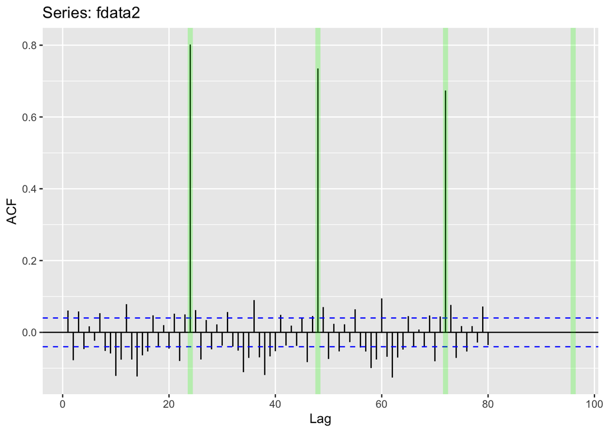

```r
freq <- 24
ggAcf(fdata2, lag.max = 80)+
  geom_vline(xintercept = (1:4) * freq, color = "green", alpha = 0.25, size=2)
```

Applying a seasonal difference

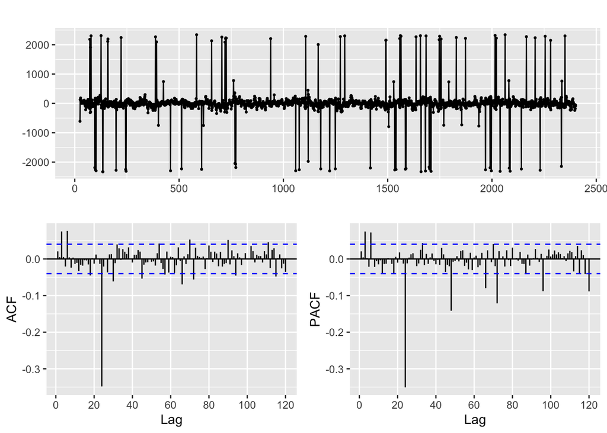

```r
ggtsdisplay(diff(fdata2, lag = freq), lag.max = 5 * freq)
```

## Identification and fitting process

Let us return to the Car Registration example

### Box-Cox transformation

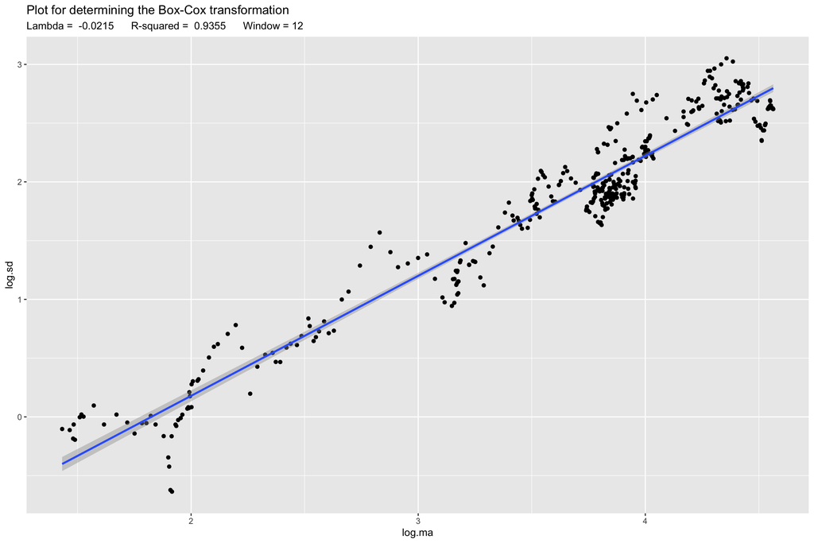

```r
# Line 48 of Lab4
Lambda <- BoxCox.lambda.plot(y.TR, window.width = 12)
```

```r
# Line 51 of Lab4
z <- BoxCox(y.TR, Lambda)
```

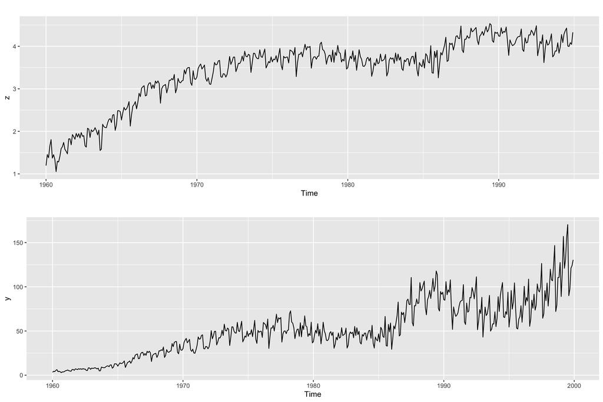

```r
# Line 39 of Lab4
p1 <- autoplot(z)
p2 <- autoplot(y)
gridExtra::grid.arrange(p1, p2, nrow = 2 )
```

### Differencing

```r
# Line 58 of Lab4
#recall if the ACF decreases very slowly -> needs differentiation
```

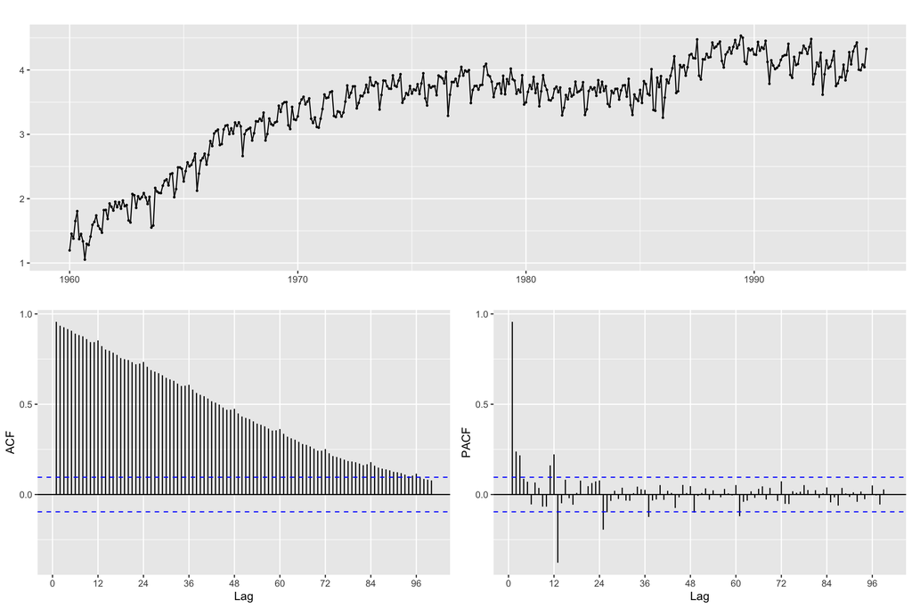

```r
ggtsdisplay(z,lag.max = 100)
```

#### Seasonal Differencing

It is generally better to start with seasonal differencing when a time series exhibits both seasonal and non-seasonal patterns.

```r
# Line 62 of Lab4
B12z<- diff(z, lag = freq, differences = 1)
```

We use the ACF and PACF to inspect the result

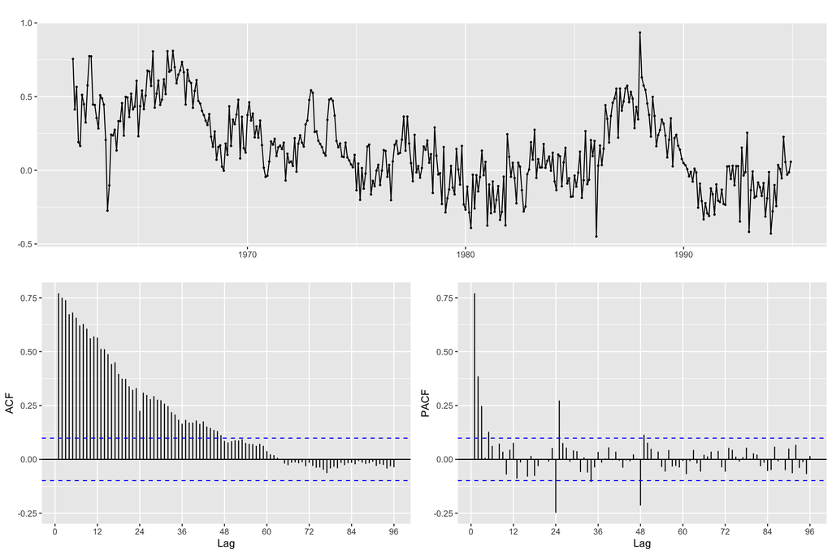

```r
ggtsdisplay(B12z,lag.max = 4 * freq)
```

#### Regular Differencing (without seasonal)

```r
# Line 66 of Lab4
Bz <- diff(z,differences = 1)
```

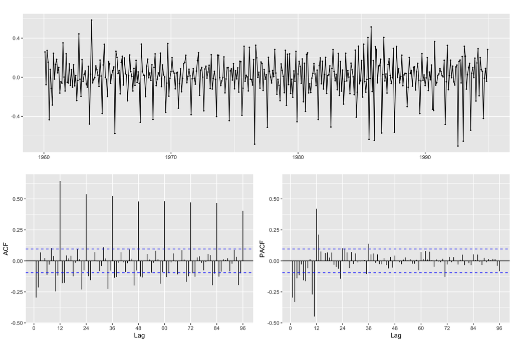

```r
ggtsdisplay(Bz, lag.max = 4 * freq)
```

#### Both regular & seasonal Differentiation

```r
# Line 70 of Lab4
B12Bz <- diff(Bz, lag = freq, differences = 1)
```

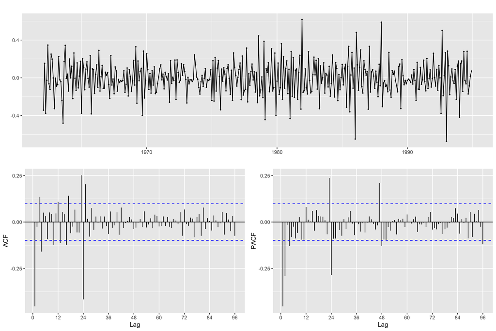

```r
ggtsdisplay(B12Bz, lag.max = 4 * freq)
```

Remember, when you apply both differences the order does not matter. Here we check that visually:

```r
B_B12z<- diff(B12z, differences = 1)
```

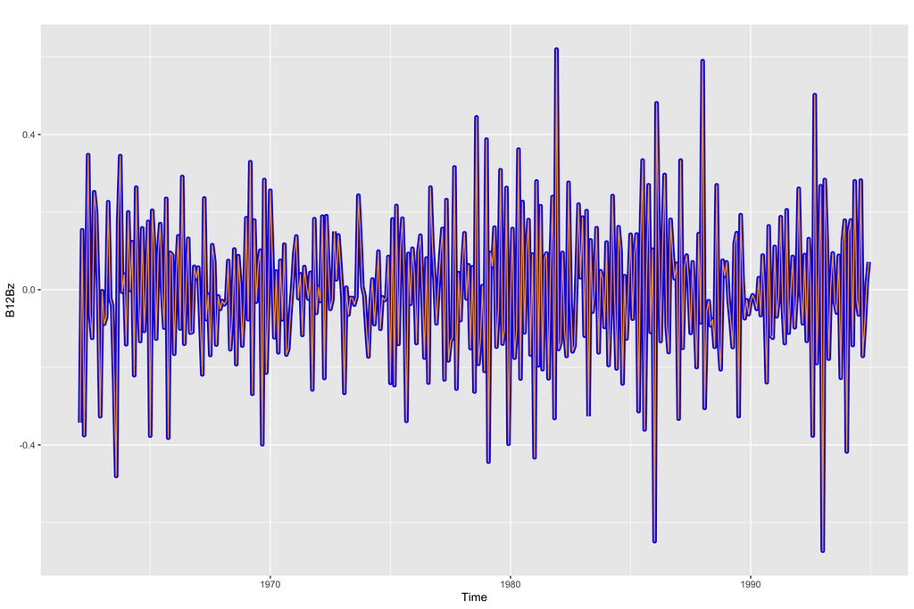

```r
# Line 75 of Lab4
autoplot(B12Bz, color = "blue", size = 2) + autolayer(B_B12z, color = "orange", size = 0.5)
```

#### Model Order (p, d, q)(P, D, Q)_s selection

Now, using the results above, we select both the regular d and the seasonal D orders of differencing and the ARMA structure, both regular and seasonal

```r
p <- 0
d <- 1
q <- 1

P <- 1
D <- 1
Q <- 1
```

### Fit seasonal model with estimated order

```r
# Line 80 (modified) of Lab4
arima.fit <- Arima(y.TR,
                   order=c(p, d, q),
                   seasonal = list(order=c(P, D, Q), period=freq),
                   lambda = Lambda,
                   include.constant = FALSE)
```

## Model Diagnosis

#### Summary of training errors and estimated coefficients

```r
# Line 86 of Lab4
summary(arima.fit)
```

```
Series: y.TR
ARIMA(0,1,1)(1,1,1)[24]
Box Cox transformation: lambda= -0.02149828

Coefficients:
          ma1    sar1     sma1
      -0.5997  0.0877  -0.8988
s.e.   0.0432  0.0670   0.0655

sigma^2 = 0.01475:  log likelihood = 255.92
AIC=-503.83   AICc=-503.73   BIC=-487.92

Training set error measures:
                    ME     RMSE      MAE       MPE     MAPE      MASE
Training set -0.432281 6.160028 4.327191 -2.242973 9.844774 0.6289316
                    ACF1
Training set -0.03946431
```

#### Statistical significance of estimated coefficients

```r
# Line 87 of Lab4
coeftest(arima.fit)
```

```
z test of coefficients:

      Estimate Std. Error  z value Pr(>|z|)
ma1  -0.599729   0.043169 -13.8927   <2e-16 ***
sar1  0.087686   0.066970   1.3093   0.1904
sma1 -0.898751   0.065466 -13.7285   <2e-16 ***
---
Signif. codes:  0 '***' 0.001 '**' 0.01 '*' 0.05 '.' 0.1 ' ' 1
```

#### Root plot

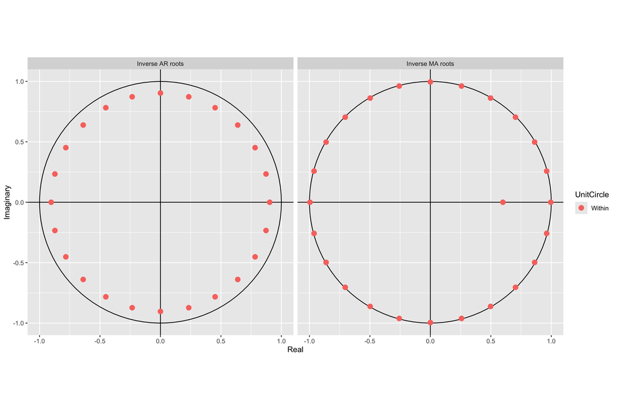

```r
# Line 88 of Lab4
autoplot(arima.fit)
```

#### Check residuals

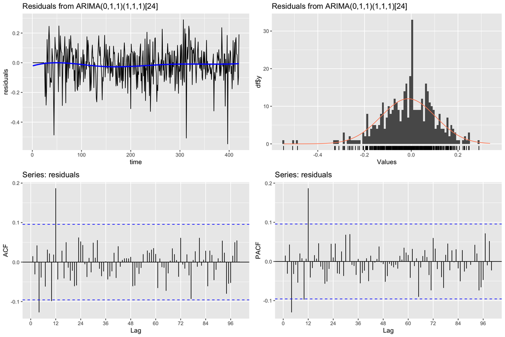

```
    Ljung-Box test

data:  Residuals from ARIMA(0,1,1)(1,1,1)[24]
Q* = 89.452, df = 97, p-value = 0.6944

Model df: 3.   Total lags used: 100
```

```r
# Line 91 of Lab4
CheckResiduals.ICAI(arima.fit, bins = 100, lag=100)
```

If residuals are not white noise, change order of ARMA

#### Check the fitted values

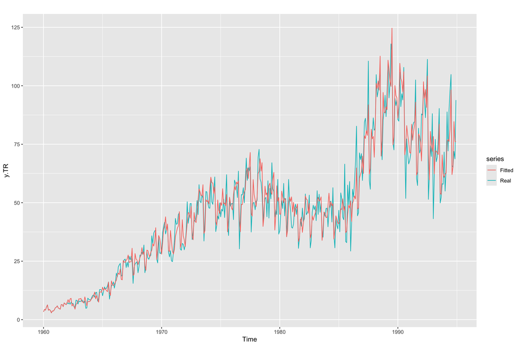

```r
# Line 94 of Lab4
autoplot(y.TR, series = "Real") +
  forecast::autolayer(arima.fit$fitted, series = "Fitted")
```

## Future forecast and validation

```r
# Line 99 of Lab4
y_est <- forecast::forecast(y.TR, model=arima.fit, h=freq)
head(y_est$mean, n = 12)
```

```
           Jan       Feb       Mar       Apr       May       Jun       Jul
1995  72.24402  77.72355  92.74988  87.79493  89.38275  91.23070 104.15455
           Aug       Sep       Oct       Nov       Dec
1995  64.00357  66.17088  84.55637  82.06407  85.81810
```

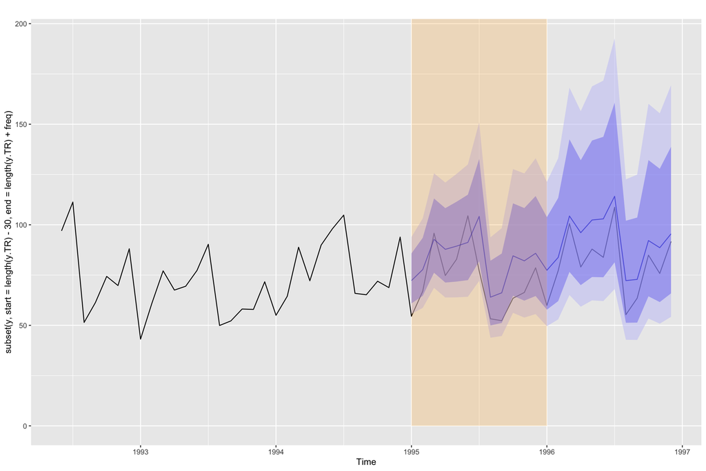

```r
xmin <- 1995
xmax <- 1996
ymin <- 0
ymax <- Inf

autoplot(subset(y, start=length(y.TR) - 30, end=length(y.TR) + freq)) +
  autolayer(y_est, alpha = 0.5) +
  annotate("rect", xmin=xmin, xmax=xmax, ymin=ymin, ymax= ymax, alpha=0.2, fill="orange")
```

### Validation error for h = 1

Obtain the forecast in validation for horizon = 1 using the trained parameters of the model. We loop through the validation period, adding one point of the time series each time and forecasting the next value (h = 1).

```r
# Line 104 of Lab4
y.TV.est <- y * NA
```

```r
# Line 106  of Lab4
for (i in seq(length(y.TR) + 1, length(y), 1)){
  y.TV.est[i] <- forecast::forecast(subset(y, end=i-1),
                          model = arima.fit,
                          h=1)$mean
}
```

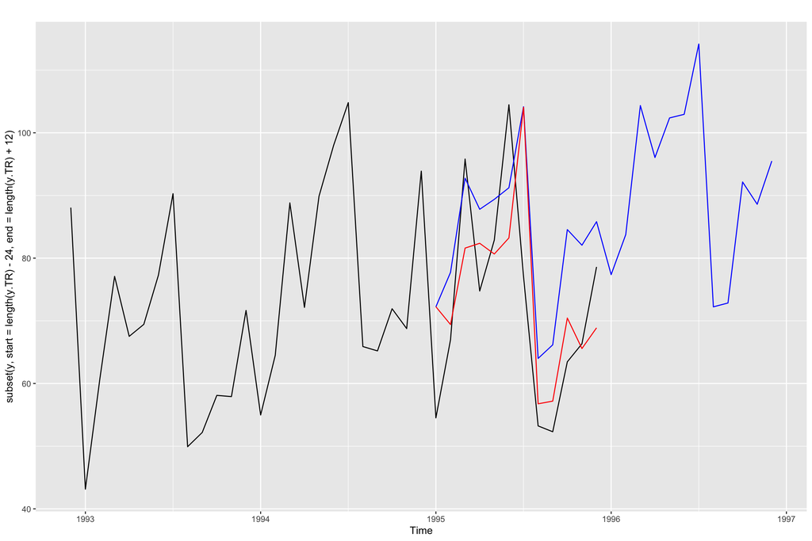

```r
# Line 116 of Lab4
autoplot(subset(y, start=length(y.TR) - 24, end = length(y.TR) + 12)) +
  forecast::autolayer(y_est$mean, color="blue") +
  forecast::autolayer(subset(y.TV.est, start = length(y.TR) + 1,
                             end = length(y.TR) + 12), color="red")
```

Finally we compute the validation errors

```r
# Line 120 of Lab4
accuracy(subset(y.TV.est, start = length(y.TR) + 1), y)
```

```
               ME     RMSE     MAE        MPE     MAPE      ACF1 Theil's U
Test set 1.643639 10.10724 7.91742 0.04251236 8.459256 -0.238131  0.425696
```

Uncomment the following line to see the direct computation of RSME

```r
sqrt(mean((y.TV.est - y.TV)^2))
```

```
[1] 10.10724
```

## Additional Code

We have seen above that the result of using forecast is different from the result of the validation loop. Both are using the fitted model to forecast, so what is the difference?

Below we will explicitly use the fitted model coefficients to obtain the forecasted values, both for the validation loop and for the `forecast` function. Keep in mind that the Arima function incorporates the BoxCox transformation. So to make things simpler, we will work directly with z instead of y.

- When you start forecasting the first values you replace past values of $z$ with training set values and $\epsilon$ values with the residuals of the fitted model (also corresponding to training). As you move further into the test set, unknown values of $z$ and $\epsilon$ will be needed.
- Note that in order to compute $z_t$ using the first equation we need $\epsilon_t$, so we assume that value to be zero.
- The main difference between `forecast` and the validation loop is in deciding whether we then use the second equation to update $\epsilon_t$ for $t$ values corresponding to the test set. Let us explore this in the code.

So we begin by splitting z into training and test.

**Technical note:** Lambda was determined using only the training set, and we apply the same Lambda to the test set to prevent data leakage.

```r
z <- BoxCox(y, Lambda)
z.TR <- subset(z, end = length(y.TR))
z.TV <- subset(z, start = length(y.TR) + 1)
```

We fit a seasonal model to z with the same order we used for y, but setting lambda equal to 1.

```r
arima.fit <- Arima(z.TR,
                   order=c(p, d, q),
                   seasonal = list(order=c(P, D, Q), period=12),
                   lambda = 1,
                   include.constant = FALSE)
```

```r
summary(arima.fit)
```

```
Series: z.TR
ARIMA(0,1,1)(1,1,1)[12]
Box Cox transformation: lambda= 1

Coefficients:
          ma1    sar1     sma1
      -0.5936  0.2317  -0.9189
s.e.   0.0435  0.0611   0.0394

sigma^2 = 0.01329:  log likelihood = 294.41
AIC=-580.82   AICc=-580.72   BIC=-564.78

Training set error measures:
                       ME      RMSE        MAE        MPE     MAPE      MASE
Training set -0.008851713 0.1130747 0.08373548 -0.3647752 2.684318 0.5294322
                  ACF1
Training set 0.0237826
```

```r
coeftest(arima.fit)
```

```
z test of coefficients:

      Estimate Std. Error  z value  Pr(>|z|)
ma1  -0.593623   0.043516 -13.6413 < 2.2e-16 ***
sar1  0.231663   0.061055   3.7943  0.000148 ***
sma1 -0.918918   0.039365 -23.3437 < 2.2e-16 ***
---
Signif. codes:  0 '***' 0.001 '**' 0.01 '*' 0.05 '.' 0.1 ' ' 1
```

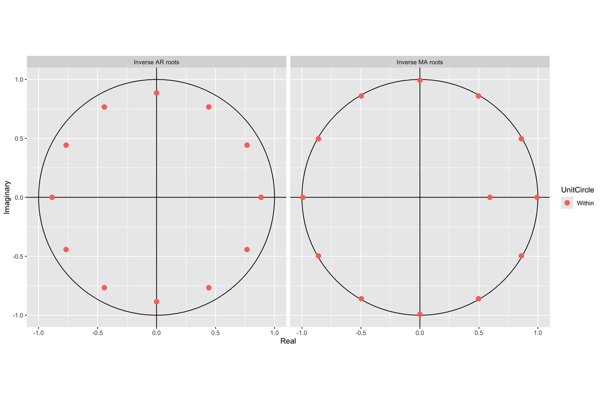

```r
autoplot(arima.fit)
```

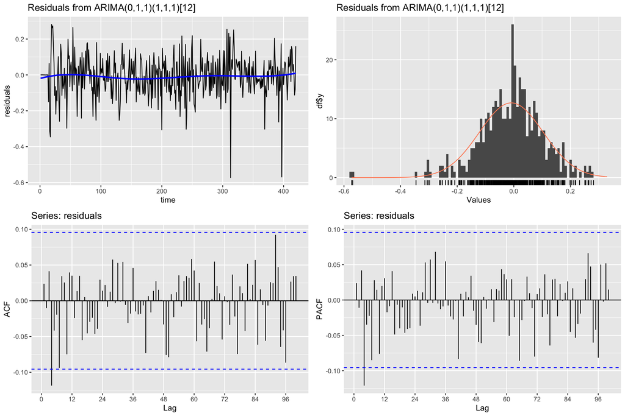

```
    Ljung-Box test

data:  Residuals from ARIMA(0,1,1)(1,1,1)[12]
Q* = 80.576, df = 97, p-value = 0.8858

Model df: 3.   Total lags used: 100
```

```r
CheckResiduals.ICAI(arima.fit, bins = 100, lag=100)
```

Now let us begin using this model to forecast the test set values.

We begin by using the `forecast` function to forecast **all the values** in the test set. That is, we set the forecasting horizon h equal to the length of the test set,

```r
z_est <- forecast::forecast(arima.fit, h=length(z.TV))
```

Next we will generate three additional versions of the forecasts, using a loop as we did before.

- The first forecast `z.TV.est` is exactly what we did before, but using z instead of y.
- The second one `z.TV.est2` will use the two forecasting equations (with the fitted coefficients) and will always use **actual values** of $z_t$ in the test set. The error terms will also be updated with the second forecasting equation.
- The third one `z.TV.est3` will also use the forecasting equation, but it will use its own **forecasted values** of $z_t$ in the test set. The error terms for $t$ in the test set will all be set to zero.

First we create empty time series to store the different forecasts.

```r
z.TV.est <- z * NA
z.TV.est2 <- z * NA
z.TV.est3 <- z * NA
```

We make the training values of $z_t$ available to the forecasting equation.

```r
z.TV.est[1:length(z.TR)] <- z.TR
z.TV.est2[1:length(z.TR)] <- z.TR
z.TV.est3[1:length(z.TR)] <- z.TR
```

Similarly, we prepare two versions of $\epsilon_t$ containing the training residuals, to be used by the second and third procedure. Even though they look initially the same, these error terms are updated differently: the second procedure really updates them with a forecast equation, whereas the third one leaves the test error values as 0.

```r
w2 <- z * 0
w2[1:length(z.TR)] <- residuals(arima.fit)

w3 <- z * 0
w3[1:length(z.TR)] <- residuals(arima.fit)
```

We store the coefficients of the model (`_s` indicates seasonal)

```r
Phi_s <- coefficients(arima.fit)["sar1"]

theta <- coefficients(arima.fit)["ma1"]
Theta_s <- coefficients(arima.fit)["sma1"]
```

And now we get the forecasts in a loop.

```r
for (i in seq(length(z.TR) + 1, length(y), 1)){# loop for validation period

  # The first one is simply what we did in the validation loop above
  z.TV.est[i] <- forecast::forecast(subset(z, end=i-1),
                                    model = arima.fit,
                                    h=1)$mean
  # In the second forecast procedure we use the two forecasting equations, with
  # real values of z and updating the errors with the second equation.
  z.TV.est2[i] <- z[i - 1] + z[i - 12] - z[i-13] +
    Phi_s * (z[i-12] - z[i-13] - z[i - 24] + z[i-25]) +
    w2[i] + theta * w2[i - 1] +  Theta_s * w2[i - 12] + theta * Theta_s * w2[i - 13]

  w2[i] = z[i] - z[i-1] - z[i-12] + z[i-13] -
    Phi_s * (z[i-12] - z[i-13] - z[i-24] + z[i-25]) -
    theta * w2[i-1] - Theta_s * w2[i-12] - theta * Theta_s * w2[i-13]

  # And in the third one we update the forecasted values z.TV.est3 using their
  # previous values and we do not update the error terms (they stay 0)
  z.TV.est3[i] <- z.TV.est3[i - 1] + z.TV.est3[i - 12] - z.TV.est3[i-13] +
    Phi_s * (z.TV.est3[i-12] - z.TV.est3[i-13] - z.TV.est3[i - 24] + z.TV.est3[i-25]) +
    w3[i] + theta * w3[i - 1] +  Theta_s * w3[i - 12] + theta * Theta_s * w3[i - 13]

}
```

Let us examine the results, comparing the first values for all the forecast procedures:

```r
k <- 10
```

Using forecast function directly (we called this s_est above):

```r
head(z_est$mean, k)
```

```
          Jan      Feb      Mar      Apr      May      Jun      Jul      Aug
1995 4.099109 4.179055 4.388351 4.294830 4.369889 4.398921 4.499703 4.063269
          Sep      Oct
1995 4.066478 4.261535
```

Using the validation loop as explained in today’s session

```r
subset(z.TV.est, start = length(z.TR) + 1, end = length(z.TR) + k)
```

```
          Jan      Feb      Mar      Apr      May      Jun      Jul      Aug
1995 4.099109 4.070260 4.258979 4.200732 4.243077 4.260375 4.427713 3.877607
          Sep      Oct
1995 3.853199 4.023954
```

Using the two forecast equations with actual z values and error updates

```r
subset(z.TV.est2, start = length(z.TR) + 1, end = length(z.TR) + k)
```

```
          Jan      Feb      Mar      Apr      May      Jun      Jul      Aug
1995 4.099130 4.070274 4.258966 4.200749 4.243050 4.260350 4.427711 3.877596
          Sep      Oct
1995 3.853198 4.023978
```

Using only the forecasting equation for y and no error update

```r
subset(z.TV.est3, start = length(z.TR) + 1, end = length(z.TR) + k)
```

```
          Jan      Feb      Mar      Apr      May      Jun      Jul      Aug
1995 4.099130 4.179070 4.388345 4.294849 4.369871 4.398893 4.499688 4.063245
          Sep      Oct
1995 4.066459 4.261540
```

The results indicate that, up to small rounding errors there are only two different results:

- the validation loop is doing what we called the second procedure.
- the `forecast` function is doing what twe called the third procedure.

The updated error values and the use of actual values of the time series explain why the validation loop produces more accurate values. This is illustrated in the plot below:

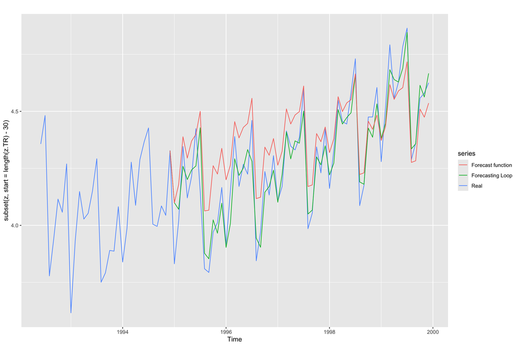

```r
autoplot(subset(z, start = length(z.TR) - 30), series="Real") +
  forecast::autolayer(subset(z.TV.est, start = length(z.TR)), series="Forecasting Loop") +
  forecast::autolayer(subset(z.TV.est3, start = length(z.TR)), series="Forecast function")
```

Now we can also compare both approaches through their validation errors.

```r
accuracy(z_est, z)
```

```
                       ME      RMSE        MAE        MPE     MAPE      MASE
Training set -0.008851713 0.1130747 0.08373548 -0.3647752 2.684318 0.5294322
Test set     -0.082613253 0.1493240 0.12528694 -2.0788377 2.996520 0.7921486
                  ACF1 Theil's U
Training set 0.0237826        NA
Test set     0.5640700 0.6401048
```

```r
accuracy(z.TV.est, z)
```

```
                   ME     RMSE         MAE         MPE      MAPE       ACF1
Test set 0.0004523453 0.030467 0.008420289 0.003263152 0.1975652 -0.1771778
         Theil's U
Test set 0.1090504
```

As expected, direct use of the `forecast` function leads to worse predictive performance in the test set.

## References

Hyndman, R. J., & Athanasopoulos, G. (2018). *Forecasting: Principles and practice, 2nd edition*. OTexts. Retrieved from https://otexts.com/fpp2/

Hyndman, R. J., & Athanasopoulos, G. (2021). *Forecasting: Principles and practice, 3rd edition*. OTexts. Retrieved from https://otexts.com/fpp3/

Krispin, R. (2019). *Hands-on time series analysis with r: Perform time series analysis and forecasting using r*. Packt Publishing Ltd. Retrieved from https://github.com/PacktPublishing/Hands-On-Time-Series-Analysis-with-R